# E.D.A.: Exploratory data analysis

Alejandro Bolaños

2019-08-18

> If the statistics are boring, then you’ve got the wrong numbers. — Edward R. Tufte

Una de las partes más importantes de nuestro trabajo es entender las variables con las que vamos a trabajar.

Primero levantamos en memoria el conjunto de datos entero, de esta forma vamos a poder explorar los mismos de forma rápida y eficiente. En caso de no disponer de un equipo con la capacidad de almacener el volumen en memoria, se podrá analizar mes a mes de forma individual, o recurrir a la nube.

```r
# Limpiamos los objectos del entorno que se encuentran memoria

rm( list=ls() )
gc()
```

```
##          used (Mb) gc trigger (Mb) max used (Mb)
## Ncells 510317 27.3    1147215 61.3   621665 33.3
## Vcells 973923  7.5    8388608 64.0  1600507 12.3
```

```r
library( "data.table")
ds  <-  data.table::fread("../datasetsOri/paquete_premium.txt", header=TRUE, sep="\t")
```

Visualizamos las primeras filas

```r
head(ds, 10)
```

| numero_de_cliente | foto_mes | marketing_activo_ultimos90dias | cliente_vip | internet | cliente_edad | cliente_antiguedad | mrentabilidad | mrentabilidad_annual | mcomisiones | mactivos_margen | mpasivos_margen | marketing_coss_selling | tpaquete1 | tpaquete2 | tpaquete3 | tpaquete4 | tpaquete5 | tpaquete6 | tpaquete7 | tpaquete8 | tpaquete9 | tcuentas | tcuenta_corriente | mcuenta_corriente_Nopaquete | mcuenta_corriente_Paquete | mcuenta_corriente_dolares | tcaja_ahorro | mcaja_ahorro_Paquete | mcaja_ahorro_Nopaquete | … |
| --- | --- | --- | --- | --- | --- | --- | --- | --- | --- | --- | --- | --- | --- | --- | --- | --- | --- | --- | --- | --- | --- | --- | --- | --- | --- | --- | --- | --- | --- | --- |
| 4566109 | 201607 | 1 | 0 | 0 | 73 | 2 | 0.26 | 0.32 | 0 | 0.23 | 0 | 7 | 1 | 0 | 0 | 0 | 0 | 0 | 0 | 0 | 0 | 1 | 1 | 0 | -10.74 | 0 | 2 | 0 | 0 | … |
| 4566109 | 201608 | 1 | 0 | 0 | 73 | 3 | 0.29 | 0.62 | 0 | 0.25 | 0 | 7 | 1 | 0 | 0 | 0 | 0 | 0 | 0 | 0 | 0 | 1 | 1 | 0 | -11.33 | 0 | 2 | 0 | 0 | … |
| 4566109 | 201609 | 0 | 0 | 0 | 73 | 4 | 0.32 | 0.94 | 0 | 0.28 | 0 | 7 | 1 | 0 | 0 | 0 | 0 | 0 | 0 | 0 | 0 | 1 | 1 | 0 | -12.15 | 0 | 2 | 0 | 0 | … |
| 4566109 | 201610 | 0 | 0 | 0 | 74 | 5 | 0.36 | 1.31 | 0 | 0.31 | 0 | 6 | 1 | 0 | 0 | 0 | 0 | 0 | 0 | 0 | 0 | 1 | 1 | 0 | -12.96 | 0 | 2 | 0 | 0 | … |
| 4566109 | 201611 | 0 | 0 | 0 | 74 | 6 | 0.38 | 1.69 | 0 | 0.33 | 0 | 6 | 1 | 0 | 0 | 0 | 0 | 0 | 0 | 0 | 0 | 1 | 1 | 0 | -13.79 | 0 | 2 | 0 | 0 | … |
| 4566109 | 201612 | 0 | 0 | 0 | 74 | 7 | 0.45 | 2.15 | 0 | 0.39 | 0 | 6 | 1 | 0 | 0 | 0 | 0 | 0 | 0 | 0 | 0 | 1 | 1 | 0 | -14.73 | 0 | 2 | 0 | 0 | … |
| 4566109 | 201701 | 0 | 0 | 0 | 74 | 8 | 0.47 | 2.63 | 0 | 0.41 | 0 | 6 | 1 | 0 | 0 | 0 | 0 | 0 | 0 | 0 | 0 | 1 | 1 | 0 | -15.64 | 0 | 2 | 0 | 0 | … |
| 4566109 | 201702 | 0 | 0 | 0 | 74 | 9 | 0.44 | 3.07 | 0 | 0.38 | 0 | 6 | 1 | 0 | 0 | 0 | 0 | 0 | 0 | 0 | 0 | 1 | 1 | 0 | -16.71 | 0 | 2 | 0 | 0 | … |
| 4566109 | 201703 | 0 | 0 | 0 | 74 | 10 | 0.53 | 3.61 | 0 | 0.46 | 0 | 6 | 1 | 0 | 0 | 0 | 0 | 0 | 0 | 0 | 0 | 1 | 1 | 0 | -17.77 | 0 | 2 | 0 | 0 | … |
| 4566109 | 201704 | 0 | 0 | 0 | 74 | 11 | 0.56 | 4.17 | 0 | 0.48 | 0 | 6 | 1 | 0 | 0 | 0 | 0 | 0 | 0 | 0 | 0 | 1 | 1 | 0 | -18.94 | 0 | 2 | 0 | 0 | … |

Leamos la descripción de las variables compartida en el DropBox, identifiquemos que tipo de variables son:

- Numérica
- Categórica
- Ordinal

Empezamos poniendo el foco sobre la variable target mes a mes, tratamos de entender la cantidad de churn

```r
ds_foto_mes <- dcast(ds, foto_mes ~ clase_ternaria,
                     length,
                     subset = (foto_mes <= 201904),
                     value.var = "clase_ternaria" )
ds_foto_mes
```

| foto_mes | BAJA+1 | BAJA+2 | CONTINUA |
| --- | --- | --- | --- |
| 201607 | 256 | 553 | 139481 |
| 201608 | 559 | 492 | 141714 |
| 201609 | 494 | 487 | 143899 |
| 201610 | 487 | 546 | 145812 |
| 201611 | 549 | 592 | 147770 |
| 201612 | 593 | 567 | 149202 |
| 201701 | 572 | 582 | 151428 |
| 201702 | 584 | 658 | 153565 |
| 201703 | 668 | 682 | 155852 |
| 201704 | 683 | 787 | 157591 |

[output cut: 24 more lines]

Consulta: Si aplicamos el filtro anterior en el data.table y ejecutamos: ¿Por qué tarda sustancialmente más?

```r
ds_foto_mes <- dcast(ds[foto_mes <= 201904], foto_mes ~ clase_ternaria,
                     length,
                     value.var = "clase_ternaria" )
```

Gráfiquemos para empezar a entender la dinámica del problema.

```r
library(ggplot2)

# Notar que se agrega la columna sin asignación
ds_foto_mes[, c("TOTAL","x") := list(`BAJA+1` + `BAJA+2` + CONTINUA, .I) ]
ds_foto_mes
```

| foto_mes | BAJA+1 | BAJA+2 | CONTINUA | TOTAL | x |
| --- | --- | --- | --- | --- | --- |
| 201607 | 256 | 553 | 139481 | 140290 | 1 |
| 201608 | 559 | 492 | 141714 | 142765 | 2 |
| 201609 | 494 | 487 | 143899 | 144880 | 3 |
| 201610 | 487 | 546 | 145812 | 146845 | 4 |
| 201611 | 549 | 592 | 147770 | 148911 | 5 |
| 201612 | 593 | 567 | 149202 | 150362 | 6 |
| 201701 | 572 | 582 | 151428 | 152582 | 7 |
| 201702 | 584 | 658 | 153565 | 154807 | 8 |
| 201703 | 668 | 682 | 155852 | 157202 | 9 |
| 201704 | 683 | 787 | 157591 | 159061 | 10 |

[output cut: 24 more lines]

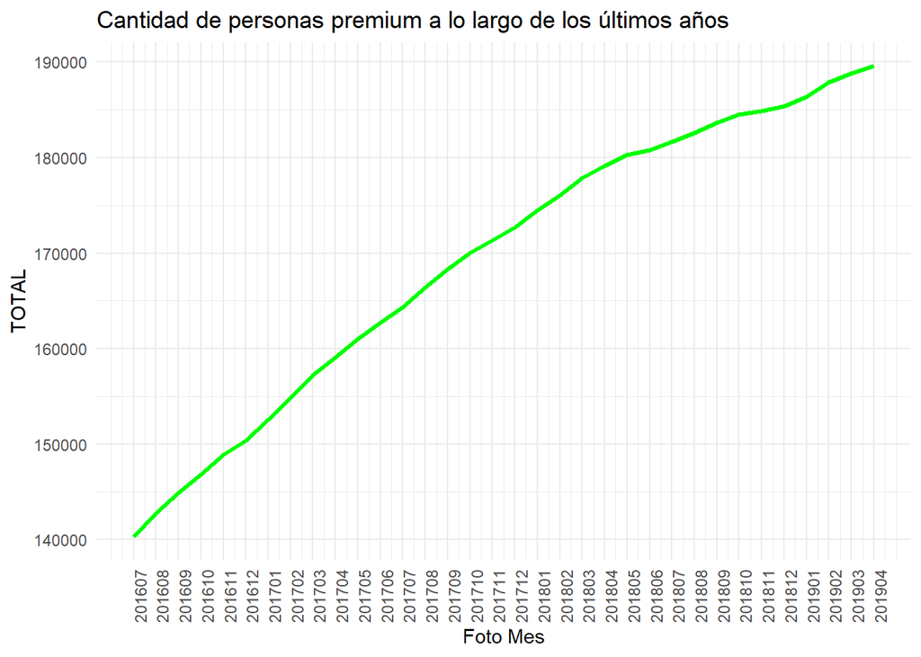

```r
ggplot(ds_foto_mes, aes(x = x, y = TOTAL))+
    geom_line(color="green", size = 1.2)+
    scale_x_continuous(labels = ds_foto_mes$foto_mes, breaks = 1:max(ds_foto_mes$x), name="Foto Mes") +
    theme_minimal() +
    theme(axis.text.x = element_text(angle = 90, hjust = 1)) +
    ggtitle("Cantidad de personas premium a lo largo de los últimos años")
```

```r
#Agregamos los ratios

ds_foto_mes[, c("R_BAJAS1","R_BAJAS2") := list(`BAJA+1` / TOTAL,`BAJA+2` / TOTAL)]
ds_foto_mes
```

| foto_mes | BAJA+1 | BAJA+2 | CONTINUA | TOTAL | x | R_BAJAS1 | R_BAJAS2 |
| --- | --- | --- | --- | --- | --- | --- | --- |
| 201607 | 256 | 553 | 139481 | 140290 | 1 | 0.001824792 | 0.003941835 |
| 201608 | 559 | 492 | 141714 | 142765 | 2 | 0.003915526 | 0.003446223 |
| 201609 | 494 | 487 | 143899 | 144880 | 3 | 0.003409718 | 0.003361403 |
| 201610 | 487 | 546 | 145812 | 146845 | 4 | 0.003316422 | 0.003718206 |
| 201611 | 549 | 592 | 147770 | 148911 | 5 | 0.003686766 | 0.003975529 |
| 201612 | 593 | 567 | 149202 | 150362 | 6 | 0.003943816 | 0.003770900 |
| 201701 | 572 | 582 | 151428 | 152582 | 7 | 0.003748804 | 0.003814342 |
| 201702 | 584 | 658 | 153565 | 154807 | 8 | 0.003772439 | 0.004250454 |
| 201703 | 668 | 682 | 155852 | 157202 | 9 | 0.004249310 | 0.004338367 |
| 201704 | 683 | 787 | 157591 | 159061 | 10 | 0.004293950 | 0.004947787 |

[output cut: 24 more lines]

```r
# Adaptamos la tabla para visualizar con ggplot
ds_ratios = melt(ds_foto_mes,id.vars = c("foto_mes", "x"),
                measure.vars = c("R_BAJAS1", "R_BAJAS2"))
ds_ratios
```

| foto_mes | x | variable | value |
| --- | --- | --- | --- |
| 201607 | 1 | R_BAJAS1 | 0.001824792 |
| 201608 | 2 | R_BAJAS1 | 0.003915526 |
| 201609 | 3 | R_BAJAS1 | 0.003409718 |
| 201610 | 4 | R_BAJAS1 | 0.003316422 |
| 201611 | 5 | R_BAJAS1 | 0.003686766 |
| 201612 | 6 | R_BAJAS1 | 0.003943816 |
| 201701 | 7 | R_BAJAS1 | 0.003748804 |
| 201702 | 8 | R_BAJAS1 | 0.003772439 |
| 201703 | 9 | R_BAJAS1 | 0.004249310 |
| 201704 | 10 | R_BAJAS1 | 0.004293950 |

[output cut: 58 more lines]

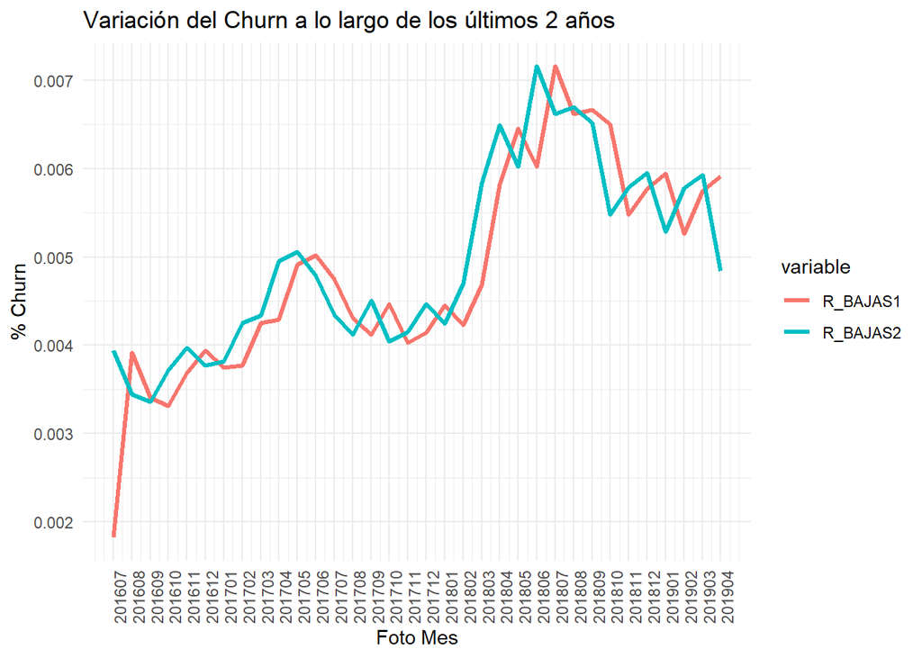

```r
ggplot(ds_ratios, aes(x = x, y = value))+
  geom_line(aes(colour = variable), size = 1.2) +
  scale_x_continuous(labels = unique(ds_ratios$foto_mes), breaks = seq(1,34,1), name="Foto Mes") +
  scale_y_continuous(name="% Churn") +
  theme_minimal() +
  theme(axis.text.x = element_text(angle = 90, hjust = 1)) +
  ggtitle("Variación del Churn a lo largo de los últimos 2 años")
```

Por último evaluemos la tasa de bajas / nuevos

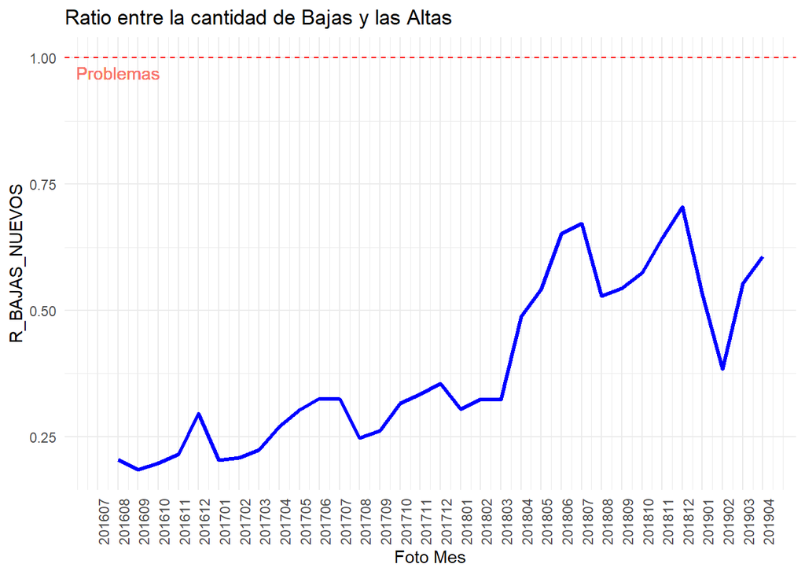

```r
ds_foto_mes[, "NUEVOS" := TOTAL - (shift(CONTINUA, 1, type="lag") + shift(`BAJA+2`, 1, type="lag"))]
ds_foto_mes[, "R_BAJAS_NUEVOS" := `BAJA+1` / NUEVOS]

ggplot(ds_foto_mes, aes(x = x, y = R_BAJAS_NUEVOS))+
    geom_line(color="blue", size = 1.2)+
    scale_x_continuous(labels = ds_foto_mes$foto_mes, breaks = 1:max(ds_foto_mes$x), name="Foto Mes") +
    geom_hline(yintercept=1, linetype="dashed", color = "red") +
    geom_text(aes(2,.97,label = "Problemas", color="red"), show.legend = FALSE) +
    theme_minimal() +
    theme(axis.text.x = element_text(angle = 90, hjust = 1)) +
    ggtitle("Ratio entre la cantidad de Bajas y las Altas")
```

Examinemos la estructura de las variables independientemente, en principio solo sobre un único mes. Exploremos a la par de la descripción de las tablas.

Veamos primero las variables del tipo texto.

```r
abril <- ds[foto_mes == 201904,]

library(skimr)
```

```r
skim_with(numeric = list(median = median, hist = NULL),
          integer = list(median = median, n_unique = n_unique, hist = NULL)
          )

desc <- as.data.table(skim_to_wide(abril))

desc[type == "character", c("variable", show_skimmers("character")[[1]])]
```

| variable | missing | complete | n | min | max | empty | n_unique |
| --- | --- | --- | --- | --- | --- | --- | --- |
| clase_ternaria | 0 | 189594 | 189594 | 6 | 8 | 0 | 3 |

Las variables de tipo punto flotante (“números reales”):

```r
desc[type == "numeric", c("variable", show_skimmers("numeric")[[1]])]
```

| variable | missing | complete | n | mean | sd | p0 | p25 | p50 | p75 | p100 | median |
| --- | --- | --- | --- | --- | --- | --- | --- | --- | --- | --- | --- |
| mactivos_margen | 0 | 189594 | 189594 | -191.8 | 1914.81 | -76356.84 | -557.49 | -118.81 | 80.79 | 377216.43 | -118.81 |
| Master_madelantodolares | 106049 | 83545 | 189594 | 0.1 | 6.61 | 0 | 0 | 0 | 0 | 1069.01 | NA |
| Master_madelantopesos | 106049 | 83545 | 189594 | 88.45 | 1080.46 | 0 | 0 | 0 | 0 | 47047.45 | NA |
| Master_mconsumosdolares | 106049 | 83545 | 189594 | 48.11 | 382.53 | 0 | 0 | 0 | 0 | 61905.22 | NA |
| Master_mconsumospesos | 106049 | 83545 | 189594 | 8281.9 | 24073.35 | -25120.01 | 0 | 1772.55 | 7711.17 | 2724449.02 | NA |
| Master_mconsumototal | 106049 | 83545 | 189594 | 8281.9 | 24073.35 | -25120.01 | 0 | 1772.55 | 7711.17 | 2724449.02 | NA |
| Master_mfinanciacion_limite | 23034 | 166560 | 189594 | 2491034.69 | 1.3e+07 | 0 | 63180 | 126360 | 332428.82 | 4.3e+08 | NA |
| Master_mlimitecompra | 23034 | 166560 | 189594 | 283045.17 | 342584.49 | 982.8 | 70200 | 140400 | 351723.06 | 1e+07 | NA |
| Master_mpagado | 23034 | 166560 | 189594 | 789.12 | 6964.45 | 0 | 0 | 0 | 0 | 452860.2 | NA |
| Master_mpagominimo | 23034 | 166560 | 189594 | 1103.22 | 8027.66 | 0 | 0 | 0 | 339.3 | 1482062.4 | NA |

[output cut: 65 more lines]

Y las variables con números enteros:

```r
desc[type == "integer", c("variable", show_skimmers("integer")[[1]])]
```

| variable | missing | complete | n | mean | sd | p0 | p25 | p50 | p75 | p100 | median | n_unique |
| --- | --- | --- | --- | --- | --- | --- | --- | --- | --- | --- | --- | --- |
| cautoservicio_transacciones | 0 | 189594 | 189594 | 0 | 0 | 0 | 0 | 0 | 0 | 0 | 0 | 1 |
| ccajeros_ajenos_transacciones | 0 | 189594 | 189594 | 1 | 2.29 | 0 | 0 | 0 | 1 | 49 | 0 | 42 |
| ccajeros_propio_transacciones | 0 | 189594 | 189594 | 2.08 | 3.6 | 0 | 0 | 0 | 3 | 87 | 0 | 58 |
| ccajeros_propios_descuentos | 0 | 189594 | 189594 | 0.1 | 0.64 | 0 | 0 | 0 | 0 | 22 | 0 | 23 |
| ccallcenter_transacciones | 0 | 189594 | 189594 | 0.9 | 3.12 | 0 | 0 | 0 | 0 | 131 | 0 | 75 |
| ccambio_monedas_compra | 0 | 189594 | 189594 | 0.14 | 0.67 | 0 | 0 | 0 | 0 | 49 | 0 | 22 |
| ccambio_monedas_venta | 0 | 189594 | 189594 | 0.22 | 0.83 | 0 | 0 | 0 | 0 | 115 | 0 | 34 |
| ccheques_depositados | 0 | 189594 | 189594 | 0.2 | 2.46 | 0 | 0 | 0 | 0 | 820 | 0 | 64 |
| ccheques_depositados_rechazados | 0 | 189594 | 189594 | 0.012 | 0.17 | 0 | 0 | 0 | 0 | 20 | 0 | 15 |
| ccheques_emitidos | 0 | 189594 | 189594 | 0.24 | 2.14 | 0 | 0 | 0 | 0 | 141 | 0 | 85 |

[output cut: 84 more lines]

- ¿Qué significa que una variable numérica tenga solo 5 valores distintos?
- ¿Es útil una variable categórica con 120 valores distintos?
- ¿Cómo son las variables fechas?
- ¿Cómo supone que van a afectar los valores ausentes?

Veamos como se comporta una variable a través de la historia, tomando una cualquiera sin pensar en el problema.

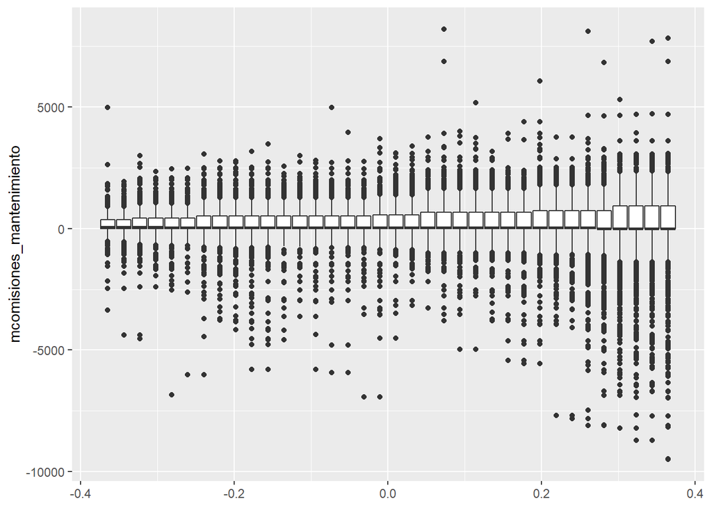

```r
ggplot(ds, aes(group=foto_mes, y=mcomisiones_mantenimiento)) + geom_boxplot()
```

- ¿Por qué se expande la distribución mes a mes?

Veamoslo con un poco de zoom:

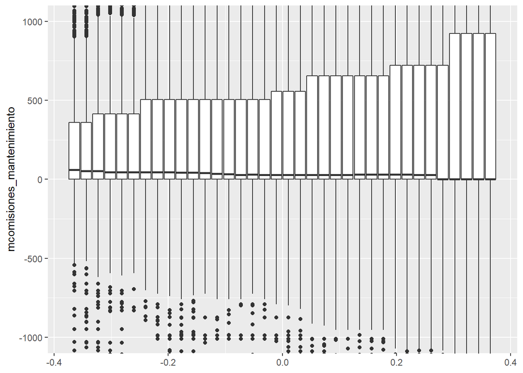

```r
ggplot(ds, aes(group=foto_mes, y=mcomisiones_mantenimiento)) +
  geom_boxplot() +
  coord_cartesian(ylim = c(-1000, 1000))
```

- ¿Qué sucede con la mediana?

Y numéricamente

```r
ds[,.(mediana = median(mcomisiones_mantenimiento),
                       minimo = min(mcomisiones_mantenimiento),
                       maximo = max(mcomisiones_mantenimiento),
                       media = mean(mcomisiones_mantenimiento)), by = foto_mes]
```

| foto_mes | mediana | minimo | maximo | media |
| --- | --- | --- | --- | --- |
| 201607 | 60.84 | -3352.49 | 4964.05 | 201.4062 |
| 201608 | 53.82 | -4382.09 | 1917.46 | 198.4662 |
| 201609 | 52.65 | -4525.17 | 2997.89 | 224.0732 |
| 201610 | 45.63 | -2406.59 | 2337.03 | 222.4925 |
| 201611 | 44.46 | -6832.20 | 2454.03 | 220.7689 |
| 201612 | 44.46 | -6009.77 | 2459.88 | 217.9275 |
| 201701 | 44.46 | -6009.77 | 3051.36 | 263.8795 |
| 201702 | 44.46 | -3767.80 | 2777.58 | 262.3656 |
| 201703 | 44.46 | -4168.71 | 2780.01 | 261.1834 |
| 201704 | 42.12 | -5798.60 | 3168.38 | 254.1156 |

[output cut: 26 more lines]

¿Y si empezamos a ver como se comportan los estadísticos según la clase?

```r
ds[,.(mediana = median(mcomisiones_mantenimiento),
                       minimo = min(mcomisiones_mantenimiento),
                       maximo = max(mcomisiones_mantenimiento),
                       media = mean(mcomisiones_mantenimiento)), by = .(foto_mes, clase_ternaria)]
```

| foto_mes | clase_ternaria | mediana | minimo | maximo | media |
| --- | --- | --- | --- | --- | --- |
| 201607 | CONTINUA | 58.500 | -3352.49 | 4964.05 | 201.1124 |
| 201608 | CONTINUA | 53.820 | -4382.09 | 1917.46 | 198.1571 |
| 201609 | CONTINUA | 47.970 | -4525.17 | 2997.89 | 223.7825 |
| 201610 | CONTINUA | 44.460 | -2406.59 | 2337.03 | 222.0825 |
| 201611 | CONTINUA | 44.460 | -6832.20 | 2454.03 | 220.3234 |
| 201612 | CONTINUA | 44.460 | -2627.79 | 2459.88 | 217.6748 |
| 201701 | CONTINUA | 44.460 | -4441.20 | 3051.36 | 263.5232 |
| 201702 | CONTINUA | 44.460 | -3767.80 | 2777.58 | 261.7492 |
| 201703 | CONTINUA | 44.460 | -4168.71 | 2780.01 | 260.5512 |
| 201704 | CONTINUA | 42.120 | -5798.60 | 3168.38 | 253.4413 |

[output cut: 95 more lines]

Apuntemos a algo más visual para ver esas diferencias:

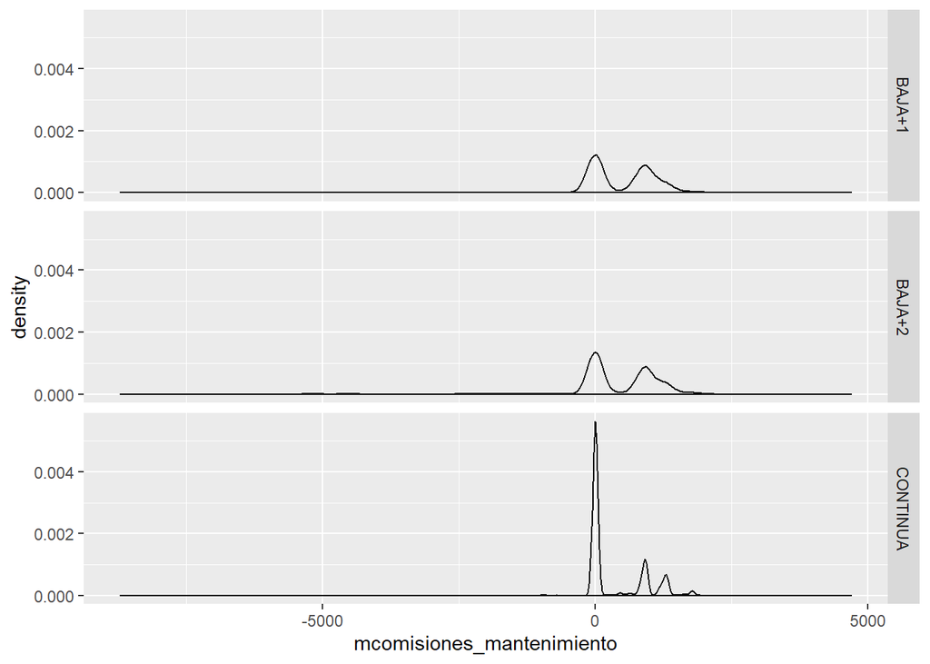

```r
# Overlaid histograms
ggplot(abril, aes(x=mcomisiones_mantenimiento)) +
  facet_grid(clase_ternaria ~ .) +
  geom_density()
```

Ya volveremos con las variables continuas, pasemos ahora a una variable categórica. Tomemos Visa_cuenta_estado (esta no la elegimos ya desde un criterio no tan aleatorio)

Vamos a ver empezar a ver de forma binaria la clase objetivo.

```r
ds_visa_estado <- dcast(abril,Visa_cuenta_estado  ~ clase_ternaria,
                        length,
                        value.var = "clase_ternaria" )

ds_visa_estado
```

| Visa_cuenta_estado | BAJA+1 | BAJA+2 | CONTINUA |
| --- | --- | --- | --- |
| NA | 327 | 238 | 6222 |
| 10 | 297 | 501 | 180630 |
| 11 | 140 | 47 | 224 |
| 12 | 73 | 97 | 236 |
| 19 | 284 | 35 | 243 |

Graficamos para darnos una idea de la potencia discriminate que tiene esta variable:

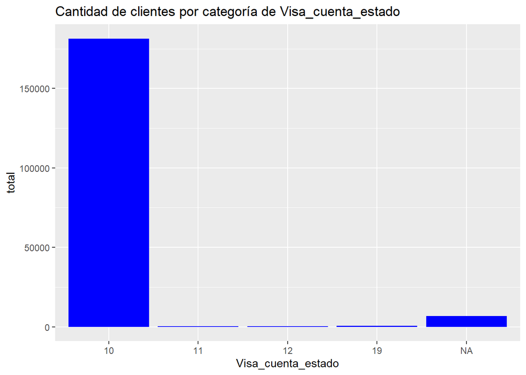

```r
ds_visa_estado[, total := (`BAJA+1`+`BAJA+2`+CONTINUA)]
ds_visa_estado[, ratio_baja := `BAJA+2` / total]
ds_visa_estado[, Visa_cuenta_estado := factor(Visa_cuenta_estado)]

# Churn en abril 2019
churn_abril = ds_foto_mes[foto_mes == 201904, R_BAJAS2]

ggplot(ds_visa_estado, aes(x=Visa_cuenta_estado, y=total)) +
  geom_bar(stat="identity", fill="blue") +
  ggtitle("Cantidad de clientes por categoría de Visa_cuenta_estado")
```

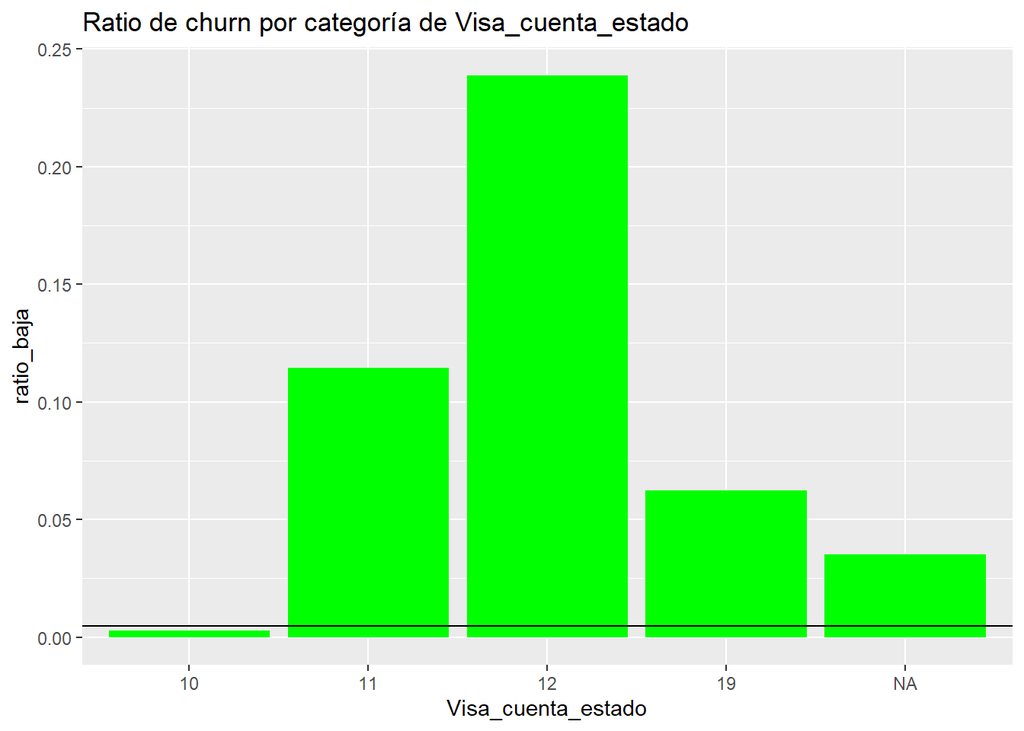

```r
ggplot(ds_visa_estado, aes(x=Visa_cuenta_estado, y=ratio_baja)) +
  geom_bar(stat="identity", fill="green") +  geom_hline(yintercept = churn_abril, color="black") +
  ggtitle("Ratio de churn por categoría de Visa_cuenta_estado")
```

Evaluemos la ganancia de cada una de las categorías para *Visa_cuenta_estado*

```r
ds_visa_estado[, Ganancia := 19500 * `BAJA+2` - 500 * (CONTINUA + `BAJA+1`) ]
ds_visa_estado
```

| Visa_cuenta_estado | BAJA+1 | BAJA+2 | CONTINUA | total | ratio_baja | Ganancia |
| --- | --- | --- | --- | --- | --- | --- |
| NA | 327 | 238 | 6222 | 6787 | 0.035067040 | 1366500 |
| 10 | 297 | 501 | 180630 | 181428 | 0.002761426 | -80694000 |
| 11 | 140 | 47 | 224 | 411 | 0.114355231 | 734500 |
| 12 | 73 | 97 | 236 | 406 | 0.238916256 | 1737000 |
| 19 | 284 | 35 | 243 | 562 | 0.062277580 | 419000 |

Y calculemos la ganancia total, si son quedamos sólo con los que nos “da de comer”

```r
cat("Ganancia =",ds_visa_estado[Ganancia > 0, sum(Ganancia)])
```

```
## Ganancia = 4257000
```

Confiados en que encontramos una buena forma de hacer dinero, sumamos la variable *Master_cuenta_estado*

```r
ds_tc_estado <- dcast(abril,Visa_cuenta_estado + Master_cuenta_estado  ~ clase_ternaria,
                        length,
                        value.var = "clase_ternaria" )
ds_tc_estado
```

| Visa_cuenta_estado | Master_cuenta_estado | BAJA+1 | BAJA+2 | CONTINUA |
| --- | --- | --- | --- | --- |
| NA | NA | 298 | 229 | 5464 |
| NA | 10 | 14 | 7 | 729 |
| NA | 11 | 7 | 2 | 13 |
| NA | 12 | 5 | 0 | 9 |
| NA | 19 | 3 | 0 | 7 |
| 10 | NA | 52 | 82 | 16507 |
| 10 | 10 | 241 | 419 | 164066 |
| 10 | 11 | 1 | 0 | 0 |
| 10 | 12 | 0 | 0 | 23 |
| 10 | 19 | 3 | 0 | 34 |

[output cut: 15 more lines]

```r
ds_tc_estado[, Ganancia := 19500 * `BAJA+2` - 500 * (CONTINUA + `BAJA+1`) ]

cat("Ganancia =",ds_tc_estado[Ganancia > 0, sum(Ganancia)])
```

```
## Ganancia = 4524000
```

- ¿Qué pasó con la ganancia? y ¿Por qué?

Una métrica muy común para las variables discretas en el mundo de los modelos de riesgo es el [Information Value](https://www.listendata.com/2015/03/weight-of-evidence-woe-and-information.html) que se calcula agrupando el WoE de cada categoría. Se puede expandir el análisis a variables númericas discretizando las mismas. Se desarrollará en un spin-off.

Veamos una interacción de la ganancia con una variable entera. Tomemos *tmovimientos_ultimos90dias*. Veamos como se distribuye con respecto a las clases:

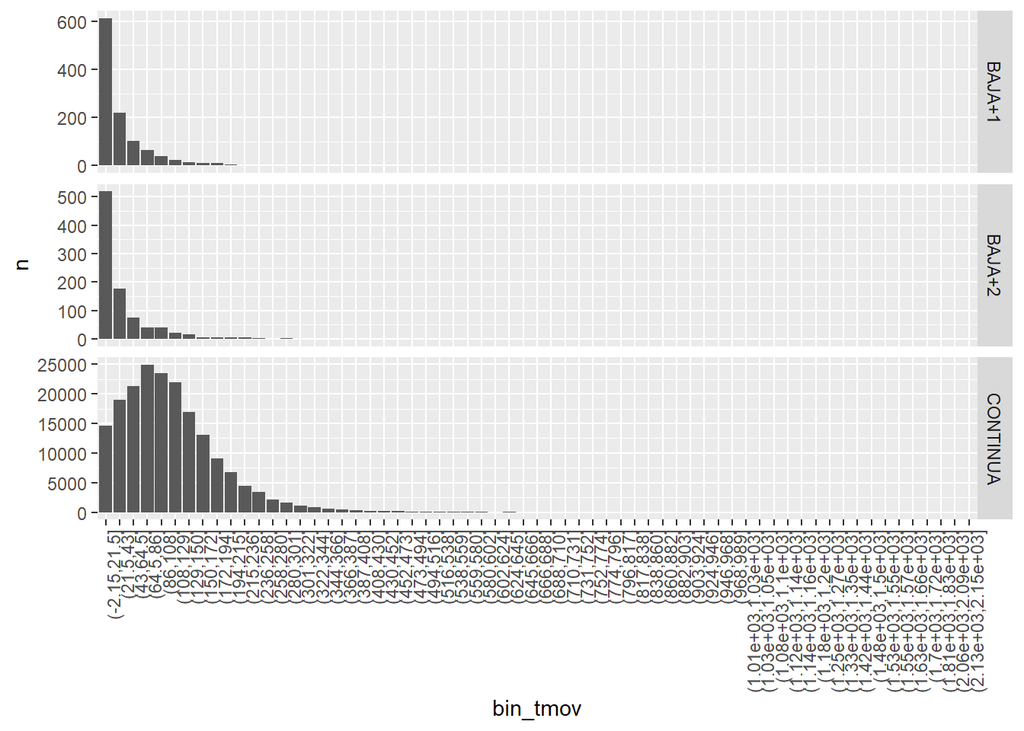

```r
abril[,bin_tmov := cut(tmovimientos_ultimos90dias, 100)]
ds_tmov <- abril[ , .(n = .N), by = .(bin_tmov,clase_ternaria)]

# Elimino la variable generada
abril[,bin_tmov:=NULL]

ggplot(ds_tmov , aes(x=bin_tmov, y = n)) +
    facet_grid(clase_ternaria ~ ., scales = "free_y") +
      theme(axis.text.x = element_text(angle = 90, hjust = 1)) +
    geom_col()
```

Calculemos la ganancia para cada entero de la variable:

```r
ds_tmov <- dcast(abril,
                 tmovimientos_ultimos90dias ~ clase_ternaria,
                 length, value.var = "clase_ternaria")

ds_tmov[, Ganancia := 19500 * `BAJA+2` - 500 * (CONTINUA + `BAJA+1`) ]

ds_tmov
```

| tmovimientos_ultimos90dias | BAJA+1 | BAJA+2 | CONTINUA | Ganancia |
| --- | --- | --- | --- | --- |
| 0 | 83 | 91 | 1313 | 1076500 |
| 1 | 18 | 17 | 262 | 191500 |
| 2 | 33 | 41 | 562 | 502000 |
| 3 | 23 | 34 | 474 | 414500 |
| 4 | 33 | 23 | 460 | 202000 |
| 5 | 23 | 25 | 403 | 274500 |
| 6 | 29 | 25 | 624 | 161000 |
| 7 | 23 | 19 | 534 | 92000 |
| 8 | 22 | 22 | 571 | 132500 |
| 9 | 33 | 33 | 676 | 289000 |

[output cut: 759 more lines]

Genero una columna con la ganancia acumulada y la cantidad que representa:

```r
ds_tmov[,gan_acum := cumsum( Ganancia )]
ds_tmov[,baja2_n := cumsum(`BAJA+2`) ]
ds_tmov[,total := cumsum(`BAJA+1` + CONTINUA) ]
ds_tmov[,ratio := baja2_n / total ]
ds_tmov
```

| tmovimientos_ultimos90dias | BAJA+1 | BAJA+2 | CONTINUA | Ganancia | gan_acum | baja2_n | total | ratio |
| --- | --- | --- | --- | --- | --- | --- | --- | --- |
| 0 | 83 | 91 | 1313 | 1076500 | 1076500 | 91 | 1396 | 0.065186246 |
| 1 | 18 | 17 | 262 | 191500 | 1268000 | 108 | 1676 | 0.064439141 |
| 2 | 33 | 41 | 562 | 502000 | 1770000 | 149 | 2271 | 0.065609863 |
| 3 | 23 | 34 | 474 | 414500 | 2184500 | 183 | 2768 | 0.066112717 |
| 4 | 33 | 23 | 460 | 202000 | 2386500 | 206 | 3261 | 0.063170807 |
| 5 | 23 | 25 | 403 | 274500 | 2661000 | 231 | 3687 | 0.062652563 |
| 6 | 29 | 25 | 624 | 161000 | 2822000 | 256 | 4340 | 0.058986175 |
| 7 | 23 | 19 | 534 | 92000 | 2914000 | 275 | 4897 | 0.056156831 |
| 8 | 22 | 22 | 571 | 132500 | 3046500 | 297 | 5490 | 0.054098361 |
| 9 | 33 | 33 | 676 | 289000 | 3335500 | 330 | 6199 | 0.053234393 |

[output cut: 759 more lines]

Y graficamos su curva de ganancia, para los primero valores que tienen sentido

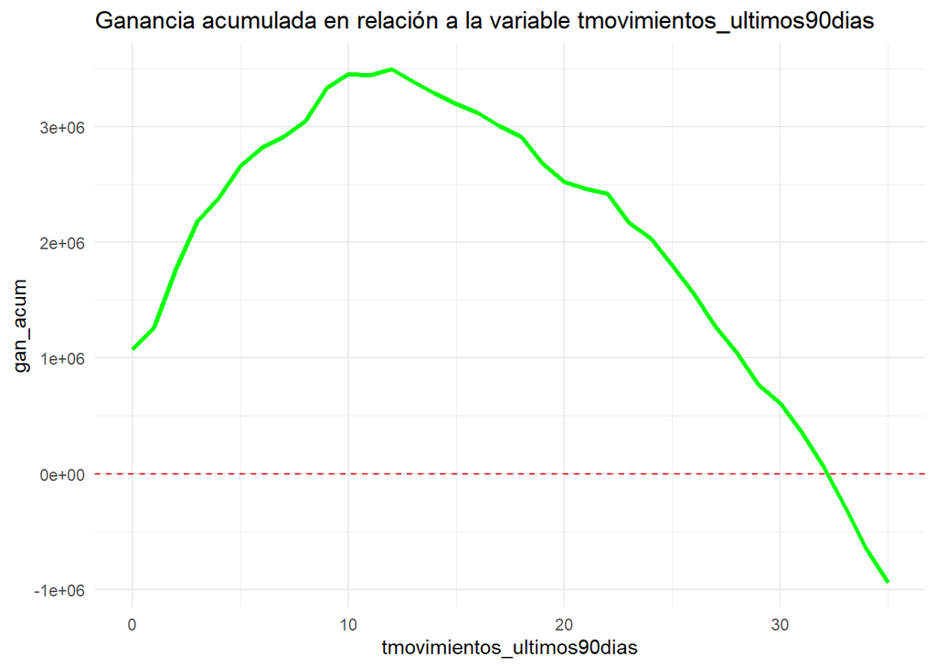

```r
ggplot(ds_tmov[tmovimientos_ultimos90dias < 36], aes(x = tmovimientos_ultimos90dias, y = gan_acum))+
    geom_line(color="green", size = 1.2)+
    theme_minimal() +
    geom_hline(yintercept=0, linetype="dashed", color = "red") +
    ggtitle("Ganancia acumulada en relación a la variable tmovimientos_ultimos90dias")
```

Nos resta volver a analizar una variable numérica con relación a la ganancia, trabajaremos con la variable *mcuentas_saldo*

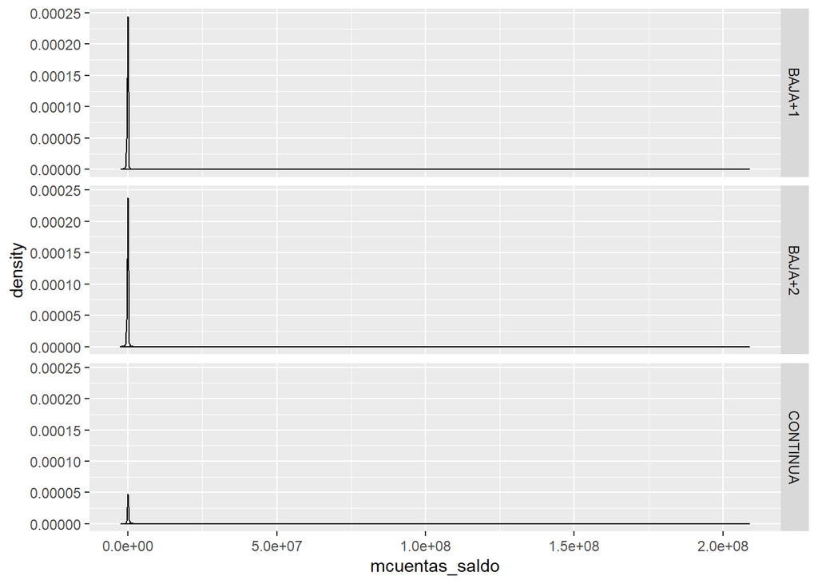

```r
ggplot(abril, aes(x=mcuentas_saldo)) +
  facet_grid(clase_ternaria ~ .) +
#  coord_cartesian(xlim=c(0,1000000)) +
  geom_density()
```

Para calcular la ganancia, vamos a cortar la variable en *n* partes, y calcularemos la ganancia de cada uno.

```r
abril[,bin_saldo := cut(mcuentas_saldo, 3000)]
ds_saldo <- dcast(abril,
                 bin_saldo ~ clase_ternaria,
                 length, value.var = "clase_ternaria")

# Elimino la variable generada
abril[,bin_saldo:=NULL]

ds_saldo[, Ganancia := 19500 * `BAJA+2` - 500 * (CONTINUA + `BAJA+1`) ]
ds_saldo[,gan_acum := cumsum( Ganancia )]
ds_saldo[,baja2_n := cumsum(`BAJA+2`) ]
ds_saldo[,total := cumsum(`BAJA+1` + CONTINUA) ]
ds_saldo[,ratio := baja2_n / total ]
ds_saldo[,n := .I ]
ds_saldo
```

| bin_saldo | BAJA+1 | BAJA+2 | CONTINUA | Ganancia | gan_acum | baja2_n | total | ratio | n |
| --- | --- | --- | --- | --- | --- | --- | --- | --- | --- |
| (-2.6408e+06,-2.3592e+06] | 1 | 0 | 1 | -1000 | -1000 | 0 | 2 | 0.000000000 | 1 |
| (-2.2184e+06,-2.148e+06] | 0 | 1 | 0 | 19500 | 18500 | 1 | 2 | 0.500000000 | 2 |
| (-2.0072e+06,-1.9368e+06] | 2 | 0 | 0 | -1000 | 17500 | 1 | 4 | 0.250000000 | 3 |
| (-1.7256e+06,-1.6552e+06] | 2 | 0 | 0 | -1000 | 16500 | 1 | 6 | 0.166666667 | 4 |
| (-1.6552e+06,-1.5848e+06] | 2 | 0 | 0 | -1000 | 15500 | 1 | 8 | 0.125000000 | 5 |
| (-1.444e+06,-1.3736e+06] | 0 | 1 | 0 | 19500 | 35000 | 2 | 8 | 0.250000000 | 6 |
| (-1.3032e+06,-1.2328e+06] | 1 | 0 | 1 | -1000 | 34000 | 2 | 10 | 0.200000000 | 7 |
| (-1.2328e+06,-1.1624e+06] | 2 | 1 | 1 | 18000 | 52000 | 3 | 13 | 0.230769231 | 8 |
| (-1.1624e+06,-1.092e+06] | 1 | 1 | 0 | 19000 | 71000 | 4 | 14 | 0.285714286 | 9 |
| (-1.092e+06,-1.0216e+06] | 1 | 0 | 1 | -1000 | 70000 | 4 | 16 | 0.250000000 | 10 |

[output cut: 343 more lines]

Gráficamos la curva de ganancia:

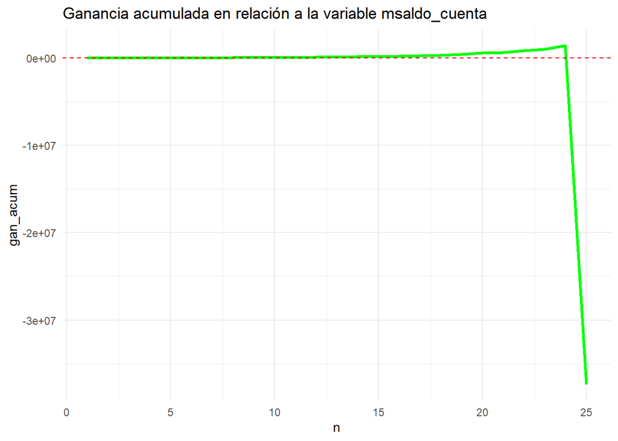

```r
ggplot(ds_saldo[n < 26], aes(x = n, y = gan_acum))+
    geom_line(color="green", size = 1.2)+
    theme_minimal() +
    geom_hline(yintercept=0, linetype="dashed", color = "red") +
    ggtitle("Ganancia acumulada en relación a la variable msaldo_cuenta")
```

Y observamos los valores máximos y donde se encuentran:

```r
# Ganancia máxima
ds_saldo[gan_acum == max(gan_acum), gan_acum]
```

```
## [1] 1457500
```

```r
# Intervalo de ganancia máxima
ds_saldo[gan_acum == max(gan_acum), bin_saldo]
```

```
## [1] (-1.0633e+05,-35933]
## 3000 Levels: (-2.6408e+06,-2.3592e+06] ... (2.087e+08,2.0899e+08]
```

Para poder como interactuan varias variables, vamos a utilizar un árbol de decisión.

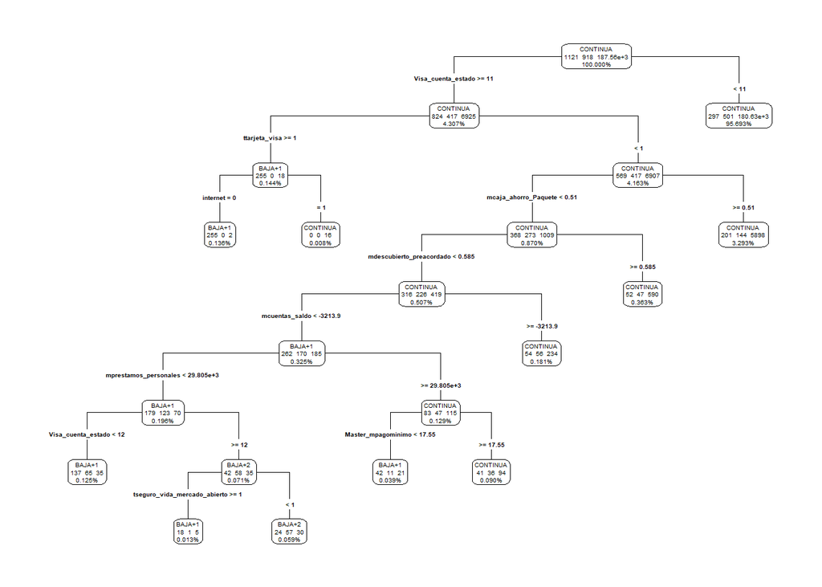

```r
library(rpart)
library( "rpart.plot" )

modelo   <-  rpart( clase_ternaria ~ .,   data = abril,   cp=0.005,  xval=0 )

# summary(modelo)

prp( modelo, extra=101, digits=5, branch=1, type=4, varlen=0, faclen=0 )
```

Y vemos cual es la importancia de las variables para entender cuales son las más discriminantes.

```r
as.data.frame(modelo$variable.importance)
```

|  | modelo$variable.importance |
| --- | --- |
| ttarjeta_visa | 787.6200743 |
| Visa_cuenta_estado | 531.5193406 |
| Visa_mfinanciacion_limite | 272.9125422 |
| mcaja_ahorro_Paquete | 222.4292387 |
| ctarjeta_visa_transacciones | 197.6387406 |
| mtarjeta_visa_consumo | 197.6387406 |
| mcuentas_saldo | 132.3249723 |
| mttarjeta_visa_debitos_automaticos | 115.1795557 |
| ttarjeta_visa_debitos_automaticos | 115.1795557 |
| mdescubierto_preacordado | 107.8355336 |

[output cut: 31 more lines]

*Preguntas*:

- ¿ Cómo podemos llevar este análisis de forma masiva al resto de las variables?
- ¿ Es posible que haya variables que se comporten parecido? ¿Como podemos detectar esos grupos de variables? ¿De que podría ser útil contar con esos grupos?
- ¿ Qué otras variables crearía para lograr explicar el churn?

*Tarea*:

- Explore otras variables tomando como guía la importancia de variables del árbol.
- Construya nuevas variables y vea que tan buenas son. Ingrese las mismas al árbol y vea en que posición se encuentran en la importancia de variables.